# Spatial repeatability results

08 July, 2025

This document contains the results of the spatial repeatability section of the repeatability project. It uses outputs from the main R script, so make sure those outputs are up-to-date before running the markdown code.

### Sample sizes for colony & species

Table 1. Sample sizes for each species, colony, and year, showing the number of individuals for which we have more than 1 foraging trip.

| Species | Colony | 1989 | 1991 | 1992 | 1993 | 1996 | 1998 | 1999 | 2001 | 2002 | 2003 | 2004 | 2005 | 2006 | 2008 | 2009 | 2010 | 2011 | 2012 | 2013 | 2014 | 2015 | 2016 | 2017 | 2018 | 2019 | 2020 | 2021 | 2022 | … |
| --- | --- | --- | --- | --- | --- | --- | --- | --- | --- | --- | --- | --- | --- | --- | --- | --- | --- | --- | --- | --- | --- | --- | --- | --- | --- | --- | --- | --- | --- | --- |
| WAAL | Crozet | 1 | 0 | 1 | 0 | 0 | 0 | 1 | 4 | 0 | 5 | 0 | 0 | 0 | 3 | 0 | 1 | 4 | 1 | 36 | 5 | 6 | 22 | 9 | 9 | 11 | 0 | 0 | 0 | … |
|  | Bird Island | 0 | 6 | 5 | 0 | 1 | 5 | 0 | 0 | 3 | 4 | 9 | 0 | 9 | 0 | 1 | 1 | 0 | 3 | 0 | 0 | 0 | 0 | 0 | 0 | 0 | 0 | 0 | 1 | … |
| BBAL | Bird Island | 0 | 0 | 0 | 5 | 0 | 0 | 0 | 0 | 10 | 0 | 0 | 0 | 0 | 1 | 0 | 0 | 0 | 0 | 0 | 0 | 24 | 0 | 0 | 0 | 3 | 8 | 3 | 6 | … |
|  | Kerguelen | 0 | 0 | 0 | 0 | 0 | 0 | 0 | 0 | 0 | 0 | 1 | 1 | 1 | 0 | 0 | 0 | 0 | 69 | 10 | 4 | 10 | 0 | 0 | 0 | 0 | 0 | 0 | 0 | … |

Table 2. Number of birds for each colony and species where trips are recorded in > 1 season.

| Species | Colony | Individuals |
| --- | --- | --- |
| BBAL | Bird Island | 48 |
|  | Kerguelen | 16 |
| WAAL | Bird Island | 7 |
|  | Crozet | 71 |

The distribution of repeats is quite patchy. Crozet WAAL have the most years of repeats, mostly falling between 2011 and 2019 (though with lots in 2024). Bird Island WAAL are quite sparsely distribution, as are the Bird Island BBAL, and the Kerguelen BBAL are mostly in 2012.

Because of this, in the across-individuals, within-years analyses I have filtered out years where only one individual is represented.

### Foraging movements

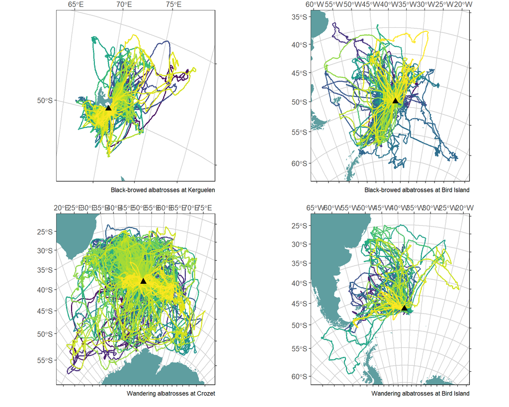

Here I’ve plotted all the GPS tracks for the different species and colonies. Note that birds from Kerguelen tend to take a NE or SW trajectory, while WAAL at Bird Island tend to go NW.

#### Example tracks from each species/colony

Here I’ve plotted a couple of examples of within- versus between-individual tracks for each species and colony. These have been cherry-picked to show individuals with similar tracks to illustrate the greatest level of within-track similarity; note that even the most similar wandering albatross tend to show a lot of variation in their trips.

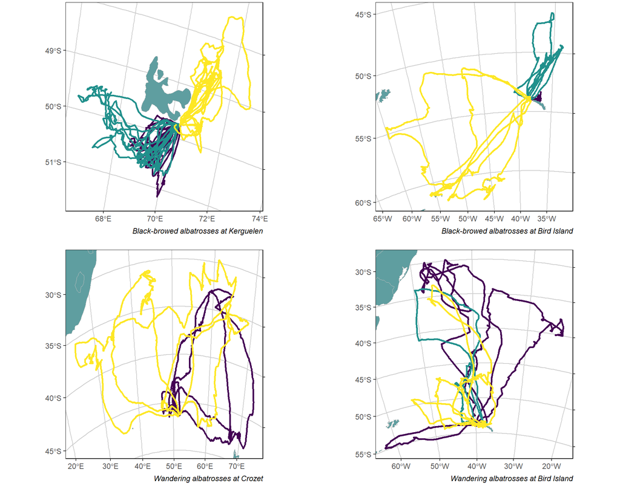

### Bearing comparisons

For these analyses, I’m looking at birds’ bearings between the colony and the furthest point of each foraging trip, which I call their ‘trajectory’. For each bird, I calculated the bearing between the colony and the distal point of each trip.

It’s important to note here that some birds’ trajectories tend to clump e.g. at Kerguelen, they clump in either a NE or a SW direction from the colony. I’m not sure if my approach deals with this effectively.

After calculating my trajectories, I then compute the **absolute differences between pairs of bearings**. I do this (i) within individual trajectories, (ii) between individual trajectories, (iii) within seasons, and (iv) between seasons. When I compute these differences, the variable is no longer circular but is rather a linear measure of angular difference that ranges from 0 to 180°. I can therefore analyse within- and between- individual/season differences using a **linear approach**.

#### Bearings from the colony

Here I’ve plotted birds’ average observed bearings from the colony.

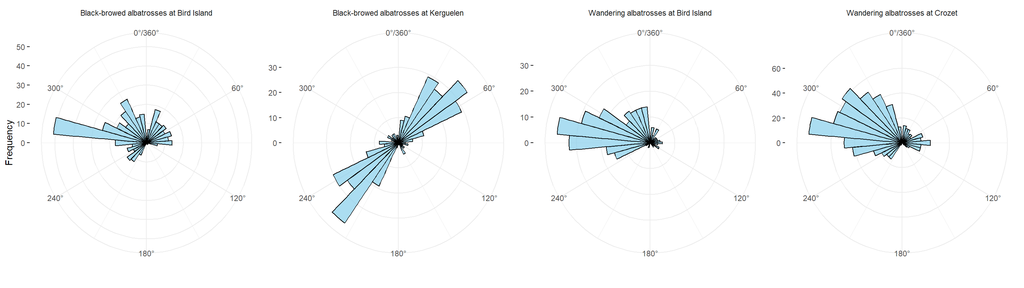

#### Modelling bearing differences

I fitted linear models to each species and colony to look at whether differences in trip trajectories were stronger among- than within-individuals (comp_ind) and/or across- or within-seasons. I’ve used linear models, rather than linear mixed-effects models, as the dyad identity (i.e. the identity of the pair, e.g. bird1_bird1 or bird1_bird2) is confounded completely by comp_ind. To avoid issues with multiple measurements, I randomly sampled one comparison from each dyad - as I started with a huge number of comparisons, this doesn’t create issues with data reduction.

I’m using the models to answer the following two questions: (1) are individuals more similar to themselves than to other birds? (2) Is this also affected by seasonality; i.e. are birds more similar to other individuals within the same season?

The model structure is as follows:

$y = \beta_0 + \beta_1 \cdot \text{comp_season} + \beta_2 \cdot \text{comp_ind} + \beta_3 \cdot (\text{comp_season} \times \text{comp_ind}) + \varepsilon$

where:

- $\beta_0$ is the intercept,
- $\beta_1$ and $\beta_2$ are the fixed effect of the comparison levels ($comp$$ind$, $comp$$season$), which compares within- vs between season/individual respectively,
- $\beta_3$ is the coefficient for the interaction term i.e. the combined effect of $comp$$ind$, and $comp$$season$.

**Prediction**: within-season and within-individual differences are smaller than across-individual and across-seasons.

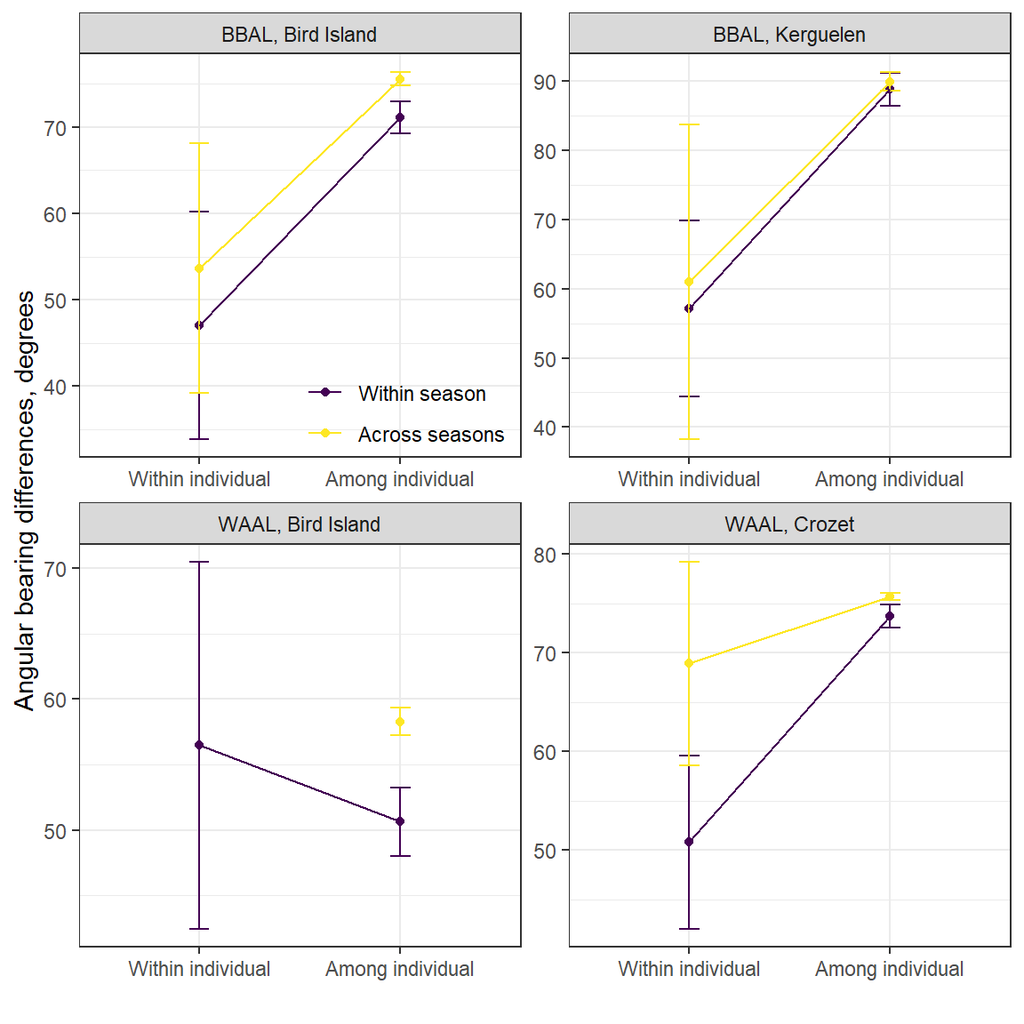

Table 2. Model outputs for trajectory comparisons. Models compared differences in bearings between the colony and the distal point of foraging trips.

| Species | Colony | Term | Estimate | CI | t value | p value |
| --- | --- | --- | --- | --- | --- | --- |
| BBA | Bird Island | Intercept | 47.02 ± 6.709 | [33.87, 60.17] | 7.009 | 0 |
|  |  | Across seasons | 6.628 ± 9.98 | [-12.93, 26.19] | 0.664 | 0.5066 |
|  |  | Among individuals | 24.11 ± 6.777 | [10.83, 37.39] | 3.558 | 0.0004 |
|  |  | Among individuals * Across seasons | -2.19 ± 10.03 | [-21.85, 17.48] | -0.218 | 0.8272 |
|  | Kerguelen | Intercept | 57.19 ± 6.485 | [44.48, 69.9] | 8.819 | 0 |
|  |  | Across seasons | 3.831 ± 13.29 | [-22.22, 29.88] | 0.288 | 0.7731 |
|  |  | Among individuals | 31.7 ± 6.598 | [18.77, 44.64] | 4.805 | 0 |
|  |  | Among individuals * Across seasons | -2.756 ± 13.36 | [-28.95, 23.43] | -0.206 | 0.8366 |
| WAAL | Bird Island | Intercept | 56.46 ± 7.143 | [42.46, 70.46] | 7.903 | 0 |
|  |  | Across seasons | 7.663 ± 1.42 | [4.88, 10.45] | 5.397 | 0 |
|  |  | Among individuals | -5.837 ± 7.264 | [-20.07, 8.4] | -0.804 | 0.4217 |
|  | Crozet | Intercept | 50.83 ± 4.478 | [42.05, 59.6] | 11.350 | 0 |
|  |  | Across seasons | 18.07 ± 6.897 | [4.555, 31.59] | 2.620 | 0.0088 |
|  |  | Among individuals | 22.89 ± 4.518 | [14.03, 31.74] | 5.066 | 0 |
|  |  | Among individuals * Across seasons | -16.1 ± 6.925 | [-29.67, -2.524] | -2.324 | 0.0201 |

### DTW comparisons

*Quick note*: originally I tried the Earth mover’s distance (EMD): this calculates the effort required to transform one image to another. In the context of GPS tracks, it quantifies the work needed to transpose one track to another. Therefore, a low EMD indicates high similarity between tracks, and a high EMD indicates low similarity. However, **this was extremely computationally intensive**, especially for long tracks.

As a result, I switched to an alternative method called **dynamic time warping**. This is much faster, and also retains the sequential structure of the track so is probably better for movement data. There is even a clustering package available called ‘dtwclust’ if I need to speed things up more quickly.

Briefly, DTW recursively compares all point combinations between two trajectories and identifies the smallest path between them. This does make it sensitive to noise, as it will also compare outliers, but this is the case for EMD too. The DTW value essentially measures the ‘warping’ needed to aling to two trajectories. As a result, a high DTW suggests low similarity, and a low DTW suggests high similarity.

There is a good write-up on DTW in [Cleasby et al. 2019, Behav Ecol Socio](https://link.springer.com/article/10.1007/s00265-019-2761-1#Sec18) that shows it performing well in comparison to several measures of trajectory similarity.

For this analysis, I used the same modelling approach as for the trip trajectories analysis, but using DTW as my response. As with the trip trajectories comparison, there are a very high number of possible comparisons, so I downsampled the between-individual datasets to 3x the size of the within-individual datasets.

#### Modelling DTW differences

The modelling approach is similar to the trip trajectory comparison; that is, I compared within individual, between individual, and between individual but within seasons. There is a heavy right skew in the DTW distances, so to account for this I log-transformed the response so it better approximates a normal distribution - I’ve taken this approach as I’m specifically interested in the differences between the comparison groups, so interpretation (which is reduced with a log transformation) is less important.

The model structure is as follows:

$log(y) = \beta_0 + \beta_1 \cdot \text{comp_season} + \beta_2 \cdot \text{comp_ind} + \beta_3 \cdot (\text{comp_season} \times \text{comp_ind}) + \varepsilon$

where:

- $\beta_0$ is the intercept,
- $\beta_1$ and $\beta_2$ are the fixed effect of the comparison levels ($comp$$ind$, $comp$$season$), which compares within- vs between season/individual respectively,
- $\beta_3$ is the coefficient for the interaction term i.e. the combined effect of $comp$$ind$, and $comp$$season$.

**Prediction**: within-season and within-individual DTW values are smaller than across-individual and across-seasons (i.e. the tracks are more similar).

[figure not shown]

| Species | Colony | Term | Estimate | CI | t value | p value |
| --- | --- | --- | --- | --- | --- | --- |
| BBA | Bird Island | Intercept | 3334 ± 867.4 | [1634, 5034] | 3.843 | 0.0001 |
|  |  | Across seasons | 339.8 ± 1327 | [-2261, 2941] | 0.256 | 0.7979 |
|  |  | Among individuals | 2147 ± 990 | [206.4, 4087] | 2.168 | 0.0303 |
|  |  | Among individuals * Across seasons | -1185 ± 1422 | [-3972, 1602] | -0.833 | 0.4048 |
|  | Kerguelen | Intercept | 405.2 ± 60.85 | [285.9, 524.4] | 6.659 | 0 |
|  |  | Across seasons | -8.081 ± 128 | [-259, 242.9] | -0.063 | 0.9497 |
|  |  | Among individuals | 86.91 ± 65.87 | [-42.2, 216] | 1.319 | 0.1872 |
|  |  | Among individuals * Across seasons | -6.87 ± 132.1 | [-265.8, 252.1] | -0.052 | 0.9585 |
| WAAL | Bird Island | Intercept | 12680 ± 2168 | [8431, 16930] | 5.849 | 0 |
|  |  | Across seasons | 2354 ± 2087 | [-1736, 6444] | 1.128 | 0.2597 |
|  |  | Among individuals | -2198 ± 2938 | [-7957, 3560] | -0.748 | 0.4546 |
|  | Crozet | Intercept | 11250 ± 1612 | [8087, 14410] | 6.976 | 0 |
|  |  | Across seasons | 9928 ± 2483 | [5062, 14790] | 3.999 | 0 |
|  |  | Among individuals | 8897 ± 2170 | [4644, 13150] | 4.101 | 0 |
|  |  | Among individuals * Across seasons | -10020 ± 2916 | [-15730, -4304] | -3.436 | 0.0006 |

### Interpretation

#### Wandering albatrosses

At Crozet, WAAL showed strong evidence of seasonal change. Bearing differences were significantly higher across seasons, indicating directional shifts in foraging between years. Likewise, DTW scores increased significantly across seasons, reflecting substantial changes in spatial trajectories over time. However, significant among-individual effects in both metrics, and a strong negative interaction in DTW, suggest that individual birds still retained some degree of consistency relative to each other, at least within seasons.

### Supplementary analyses

#### Does the seasonal interval matter for comparisons?

##### Bearings by seasonal interval

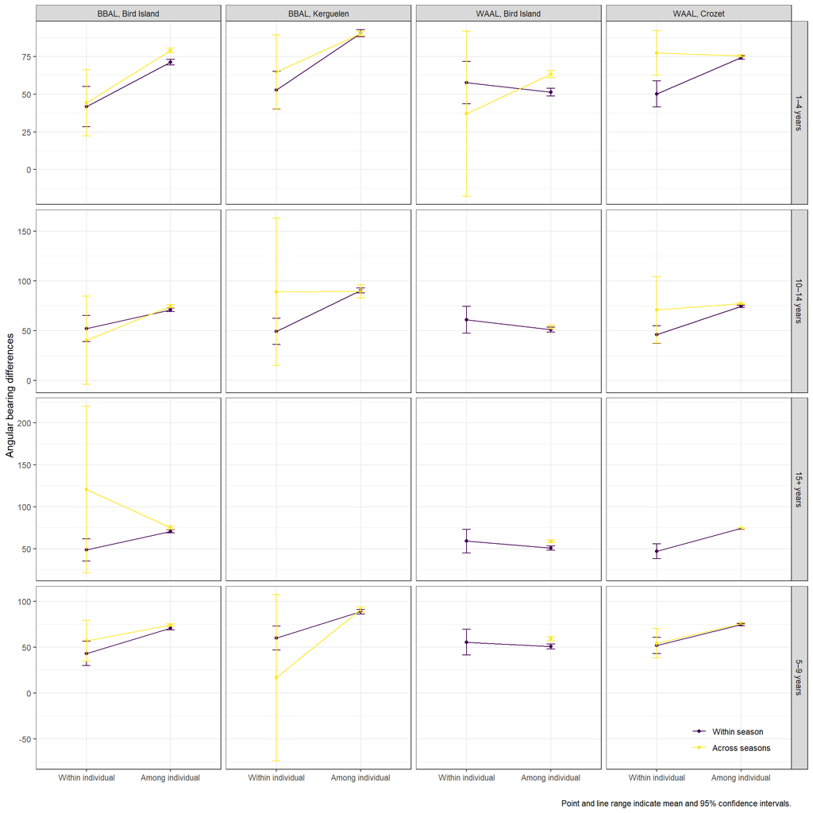

##### DTW by seasonal interval

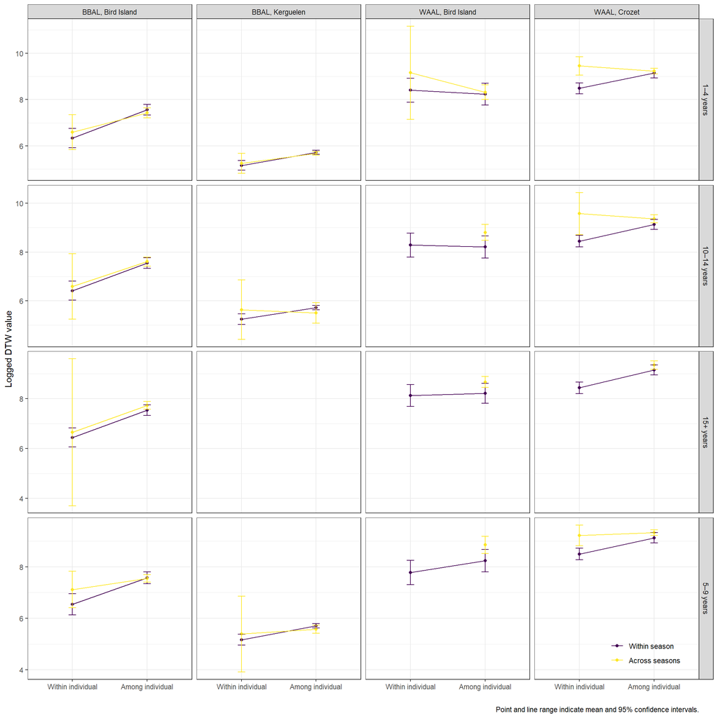

##### Overall

While there are changes in the results when using different subsets of the data according to seasonal interval, these aren’t actually very prominent. It looks like the across- and within-season comparisons hold fairly well regardless of the temporal distance between them.

#### How do the results change if we run comparisons by sex?

There are strong sex-specific distributions in the foraging locations for some of the populations, e.g. the Crozet WAAL. It’s possible that this could affect the comparisons approach - for example, a female compared to a male would always have higher DTW and trajectory differences than when compared to a random female.

##### GPS tracks by sex

Here, I’ve plotted the GPS tracks of all individuals across the colonies, coloured by sex (female = purple, male = yellow).

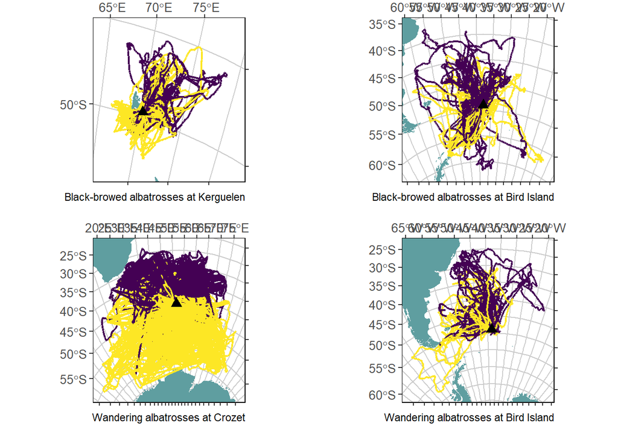

##### Bearings by sex

To determine whether this could have important effects on my results, I am re-running the analyses but restricting all comparisons to within-sex. If there are major differences in my model outputs, this suggests some of my results are being driven by sex differences.

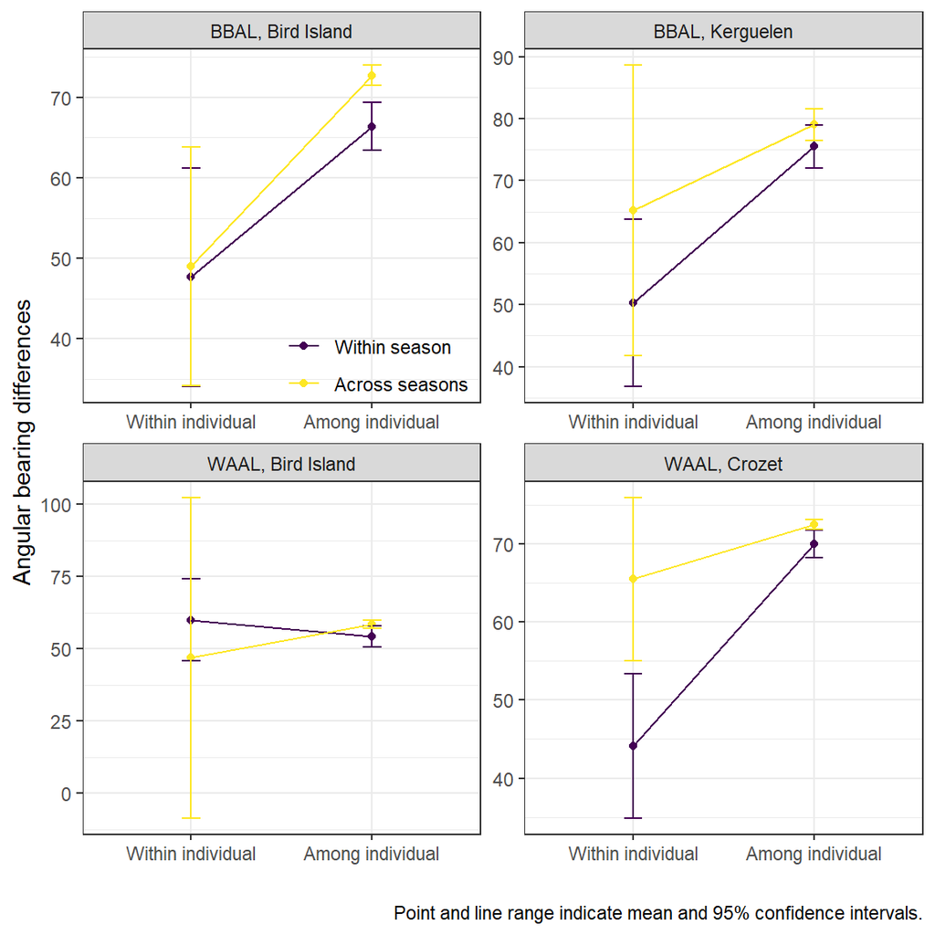

##### DTW by sex

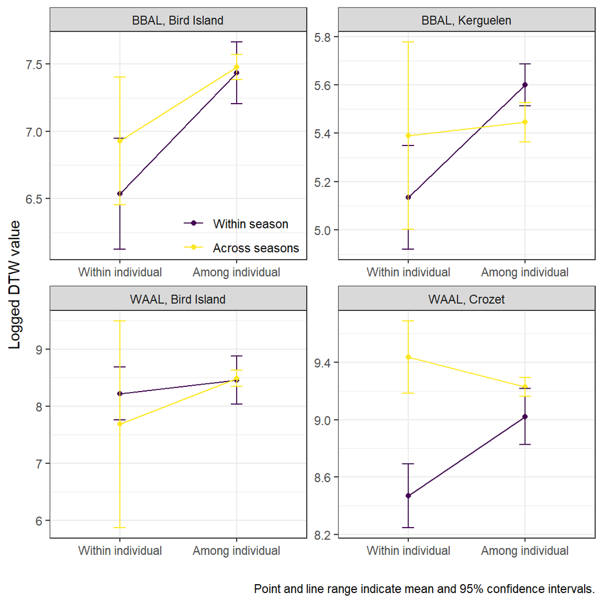

##### Overall

Looking at the outputs, there is hardly any difference between the analyses where individuals are grouped by sex and when they are not, at least for the bearing differences, so I think I’m safe to continue. I’m not interested in the effect of sex *per se*, so there’s no reason to go deeper into this.